#### Practice 3 - YELP DATASET

# Pennsylvania State restaurants rating predictions using Natural Language Processing (NLP)

#### Author : David Rivero Berrocoso

Disclaimer: In order to develop this project, we will focus on `yelp_academic-dataset_business.json` & `yelp_academic-dataset_reviews.jsonThe` . The Project will be divided in three notebooks.

### Notebook 1 - Business Dataset Understanding.

In this first notebook we will analyse the first Dataset, called `yelp_academic-dataset_business.json`, which contains a large number of american business dedicated to a wide range of sectors. In this notebook, we will find the answers to the following questions:

- Which kind of data from the businesses the dataset contains?
- Which is the current status of these businesses?
- How are these businesses distributed?
- Where are most of food-related businesses from the dataset?
- Which are the main features/categories of food-related businesses?

**Index**:

> Business Dataset Understanding & Preprocessing.

> > Mapping food-related businesses. Top categories in food-related businesses.

> > Saving Dataset for Notebook 2

```python
import pandas as pd
import matplotlib.pyplot as plt
import seaborn as sns
import geopandas as gpd
import warnings
import joblib
import re
warnings.filterwarnings("ignore")
```

## **Business Dataset Understanding & Preprocessing**

```python
df_bu = []

for chunk in pd.read_json('../data/RAW/YELP/yelp_academic_dataset_business.json', lines=True, chunksize=1000):
    df_bu.append(chunk)

df_bu = pd.concat(df_bu)
df_bu.head(10)
```

|  | business_id | name | address | city | state | postal_code | latitude | longitude | stars | review_count | is_open | attributes | categories | hours |
| --- | --- | --- | --- | --- | --- | --- | --- | --- | --- | --- | --- | --- | --- | --- |
| 0 | Pns2l4eNsfO8kk83dixA6A | Abby Rappoport, LAC, CMQ | 1616 Chapala St, Ste 2 | Santa Barbara | CA | 93101 | 34.426679 | -119.711197 | 5.0 | 7 | 0 | {'ByAppointmentOnly': 'True'} | Doctors, Traditional Chinese Medicine, Naturop... | None |
| 1 | mpf3x-BjTdTEA3yCZrAYPw | The UPS Store | 87 Grasso Plaza Shopping Center | Affton | MO | 63123 | 38.551126 | -90.335695 | 3.0 | 15 | 1 | {'BusinessAcceptsCreditCards': 'True'} | Shipping Centers, Local Services, Notaries, Ma... | {'Monday': '0:0-0:0', 'Tuesday': '8:0-18:30', ... |
| 2 | tUFrWirKiKi_TAnsVWINQQ | Target | 5255 E Broadway Blvd | Tucson | AZ | 85711 | 32.223236 | -110.880452 | 3.5 | 22 | 0 | {'BikeParking': 'True', 'BusinessAcceptsCredit... | Department Stores, Shopping, Fashion, Home & G... | {'Monday': '8:0-22:0', 'Tuesday': '8:0-22:0', ... |
| 3 | MTSW4McQd7CbVtyjqoe9mw | St Honore Pastries | 935 Race St | Philadelphia | PA | 19107 | 39.955505 | -75.155564 | 4.0 | 80 | 1 | {'RestaurantsDelivery': 'False', 'OutdoorSeati... | Restaurants, Food, Bubble Tea, Coffee & Tea, B... | {'Monday': '7:0-20:0', 'Tuesday': '7:0-20:0', ... |
| 4 | mWMc6_wTdE0EUBKIGXDVfA | Perkiomen Valley Brewery | 101 Walnut St | Green Lane | PA | 18054 | 40.338183 | -75.471659 | 4.5 | 13 | 1 | {'BusinessAcceptsCreditCards': 'True', 'Wheelc... | Brewpubs, Breweries, Food | {'Wednesday': '14:0-22:0', 'Thursday': '16:0-2... |
| 5 | CF33F8-E6oudUQ46HnavjQ | Sonic Drive-In | 615 S Main St | Ashland City | TN | 37015 | 36.269593 | -87.058943 | 2.0 | 6 | 1 | {'BusinessParking': 'None', 'BusinessAcceptsCr... | Burgers, Fast Food, Sandwiches, Food, Ice Crea... | {'Monday': '0:0-0:0', 'Tuesday': '6:0-22:0', '... |
| 6 | n_0UpQx1hsNbnPUSlodU8w | Famous Footwear | 8522 Eager Road, Dierbergs Brentwood Point | Brentwood | MO | 63144 | 38.627695 | -90.340465 | 2.5 | 13 | 1 | {'BusinessAcceptsCreditCards': 'True', 'Restau... | Sporting Goods, Fashion, Shoe Stores, Shopping... | {'Monday': '0:0-0:0', 'Tuesday': '10:0-18:0', ... |
| 7 | qkRM_2X51Yqxk3btlwAQIg | Temple Beth-El | 400 Pasadena Ave S | St. Petersburg | FL | 33707 | 27.766590 | -82.732983 | 3.5 | 5 | 1 | None | Synagogues, Religious Organizations | {'Monday': '9:0-17:0', 'Tuesday': '9:0-17:0', ... |
| 8 | k0hlBqXX-Bt0vf1op7Jr1w | Tsevi's Pub And Grill | 8025 Mackenzie Rd | Affton | MO | 63123 | 38.565165 | -90.321087 | 3.0 | 19 | 0 | {'Caters': 'True', 'Alcohol': 'u'full_bar'', '... | Pubs, Restaurants, Italian, Bars, American (Tr... | None |
| 9 | bBDDEgkFA1Otx9Lfe7BZUQ | Sonic Drive-In | 2312 Dickerson Pike | Nashville | TN | 37207 | 36.208102 | -86.768170 | 1.5 | 10 | 1 | {'RestaurantsAttire': ''casual'', 'Restaurants... | Ice Cream & Frozen Yogurt, Fast Food, Burgers,... | {'Monday': '0:0-0:0', 'Tuesday': '6:0-21:0', '... |

```python
business_dict = {
    'business_id': 'string, 22 character unique string business id',
    'name': "string, the business's name",
    'address': "string, the full address of the business",
    'city': "string, the city",
    'state': "string, 2 character state code, if applicable",
    'postal code': "string, the postal code",
    'latitude': "float, latitude",
    'longitude': "float, longitude",
    'stars': "float, star rating, rounded to half-stars",
    'review_count': "integer, number of reviews",
    'is_open': "integer, 0 or 1 for closed or open, respectively",
    'attributes': "object, business attributes to values. note: some attribute values might be objects",
    'categories': "an array of strings of business categories",
    'hours': "an object of key day to value hours, hours are using a 24hr clock"
}

pd.DataFrame.from_dict([business_dict])
```

|  | business_id | name | address | city | state | postal code | latitude | longitude | stars | review_count | is_open | attributes | categories | hours |
| --- | --- | --- | --- | --- | --- | --- | --- | --- | --- | --- | --- | --- | --- | --- |
| 0 | string, 22 character unique string business id | string, the business's name | string, the full address of the business | string, the city | string, 2 character state code, if applicable | string, the postal code | float, latitude | float, longitude | float, star rating, rounded to half-stars | integer, number of reviews | integer, 0 or 1 for closed or open, respectively | object, business attributes to values. note: s... | an array of strings of business categories | an object of key day to value hours, hours are... |

```python
print('nº of business in total:', df_bu.shape[0])
```

```
nº of business in total: 150346
```

```python
status = df_bu.groupby('is_open').business_id.count().reset_index()
status
```

|  | is_open | business_id |
| --- | --- | --- |
| 0 | 0 | 30648 |
| 1 | 1 | 119698 |

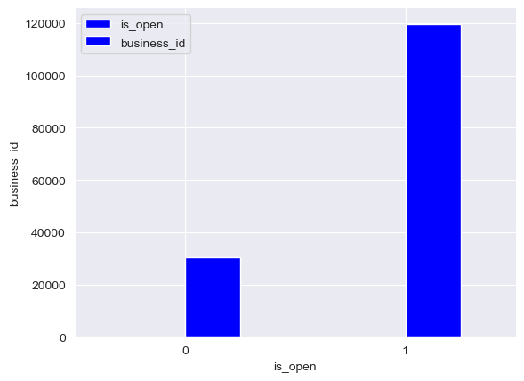

```python
status.plot(kind='bar',color='blue', rot=0)
plt.xlabel('is_open')
plt.ylabel('business_id')
sns.despine()
```

```python
# It makes no sense for this project to take into account business that have closed, so we drop them.
df_bu.drop(df_bu[df_bu.is_open == 0].index, inplace=True)
df_bu.head(10)
```

|  | business_id | name | address | city | state | postal_code | latitude | longitude | stars | review_count | is_open | attributes | categories | hours |
| --- | --- | --- | --- | --- | --- | --- | --- | --- | --- | --- | --- | --- | --- | --- |
| 1 | mpf3x-BjTdTEA3yCZrAYPw | The UPS Store | 87 Grasso Plaza Shopping Center | Affton | MO | 63123 | 38.551126 | -90.335695 | 3.0 | 15 | 1 | {'BusinessAcceptsCreditCards': 'True'} | Shipping Centers, Local Services, Notaries, Ma... | {'Monday': '0:0-0:0', 'Tuesday': '8:0-18:30', ... |
| 3 | MTSW4McQd7CbVtyjqoe9mw | St Honore Pastries | 935 Race St | Philadelphia | PA | 19107 | 39.955505 | -75.155564 | 4.0 | 80 | 1 | {'RestaurantsDelivery': 'False', 'OutdoorSeati... | Restaurants, Food, Bubble Tea, Coffee & Tea, B... | {'Monday': '7:0-20:0', 'Tuesday': '7:0-20:0', ... |
| 4 | mWMc6_wTdE0EUBKIGXDVfA | Perkiomen Valley Brewery | 101 Walnut St | Green Lane | PA | 18054 | 40.338183 | -75.471659 | 4.5 | 13 | 1 | {'BusinessAcceptsCreditCards': 'True', 'Wheelc... | Brewpubs, Breweries, Food | {'Wednesday': '14:0-22:0', 'Thursday': '16:0-2... |
| 5 | CF33F8-E6oudUQ46HnavjQ | Sonic Drive-In | 615 S Main St | Ashland City | TN | 37015 | 36.269593 | -87.058943 | 2.0 | 6 | 1 | {'BusinessParking': 'None', 'BusinessAcceptsCr... | Burgers, Fast Food, Sandwiches, Food, Ice Crea... | {'Monday': '0:0-0:0', 'Tuesday': '6:0-22:0', '... |
| 6 | n_0UpQx1hsNbnPUSlodU8w | Famous Footwear | 8522 Eager Road, Dierbergs Brentwood Point | Brentwood | MO | 63144 | 38.627695 | -90.340465 | 2.5 | 13 | 1 | {'BusinessAcceptsCreditCards': 'True', 'Restau... | Sporting Goods, Fashion, Shoe Stores, Shopping... | {'Monday': '0:0-0:0', 'Tuesday': '10:0-18:0', ... |
| 7 | qkRM_2X51Yqxk3btlwAQIg | Temple Beth-El | 400 Pasadena Ave S | St. Petersburg | FL | 33707 | 27.766590 | -82.732983 | 3.5 | 5 | 1 | None | Synagogues, Religious Organizations | {'Monday': '9:0-17:0', 'Tuesday': '9:0-17:0', ... |
| 9 | bBDDEgkFA1Otx9Lfe7BZUQ | Sonic Drive-In | 2312 Dickerson Pike | Nashville | TN | 37207 | 36.208102 | -86.768170 | 1.5 | 10 | 1 | {'RestaurantsAttire': ''casual'', 'Restaurants... | Ice Cream & Frozen Yogurt, Fast Food, Burgers,... | {'Monday': '0:0-0:0', 'Tuesday': '6:0-21:0', '... |
| 10 | UJsufbvfyfONHeWdvAHKjA | Marshalls | 21705 Village Lakes Sc Dr | Land O' Lakes | FL | 34639 | 28.190459 | -82.457380 | 3.5 | 6 | 1 | {'RestaurantsPriceRange2': '2', 'BikeParking':... | Department Stores, Shopping, Fashion | {'Monday': '9:30-21:30', 'Tuesday': '9:30-21:3... |
| 11 | eEOYSgkmpB90uNA7lDOMRA | Vietnamese Food Truck |  | Tampa Bay | FL | 33602 | 27.955269 | -82.456320 | 4.0 | 10 | 1 | {'Alcohol': ''none'', 'OutdoorSeating': 'None'... | Vietnamese, Food, Restaurants, Food Trucks | {'Monday': '11:0-14:0', 'Tuesday': '11:0-14:0'... |
| 12 | il_Ro8jwPlHresjw9EGmBg | Denny's | 8901 US 31 S | Indianapolis | IN | 46227 | 39.637133 | -86.127217 | 2.5 | 28 | 1 | {'RestaurantsReservations': 'False', 'Restaura... | American (Traditional), Restaurants, Diners, B... | {'Monday': '6:0-22:0', 'Tuesday': '6:0-22:0', ... |

```python
# We transform now 'hours' into series.
hours = df_bu['hours'].apply(pd.Series)
```

```python
# We transform attributes into series as well.
attrib = df_bu['attributes'].apply(pd.Series)
attrib.drop('BikeParking', axis = 1, inplace = True)
attrib.drop('BusinessParking', axis = 1, inplace = True)
```

```python
# We now join the datasets
attrib_hours = pd.concat([attrib, hours], axis = 1)
df_bu = pd.concat([attrib_hours, df_bu], axis = 1)
df_bu.drop(['hours', 'attributes'], axis=1, inplace=True)
df_bu
```

|  | BusinessAcceptsCreditCards | RestaurantsDelivery | OutdoorSeating | RestaurantsPriceRange2 | RestaurantsTakeOut | ByAppointmentOnly | WiFi | Alcohol | Caters | WheelchairAccessible | ... | address | city | state | postal_code | latitude | longitude | stars | review_count | is_open | categories |
| --- | --- | --- | --- | --- | --- | --- | --- | --- | --- | --- | --- | --- | --- | --- | --- | --- | --- | --- | --- | --- | --- |
| 1 | True | NaN | NaN | NaN | NaN | NaN | NaN | NaN | NaN | NaN | ... | 87 Grasso Plaza Shopping Center | Affton | MO | 63123 | 38.551126 | -90.335695 | 3.0 | 15 | 1 | Shipping Centers, Local Services, Notaries, Ma... |
| 3 | False | False | False | 1 | True | False | u'free' | u'none' | True | NaN | ... | 935 Race St | Philadelphia | PA | 19107 | 39.955505 | -75.155564 | 4.0 | 80 | 1 | Restaurants, Food, Bubble Tea, Coffee & Tea, B... |
| 4 | True | NaN | NaN | NaN | True | NaN | NaN | NaN | False | True | ... | 101 Walnut St | Green Lane | PA | 18054 | 40.338183 | -75.471659 | 4.5 | 13 | 1 | Brewpubs, Breweries, Food |
| 5 | True | True | True | 1 | True | False | u'no' | u'none' | False | True | ... | 615 S Main St | Ashland City | TN | 37015 | 36.269593 | -87.058943 | 2.0 | 6 | 1 | Burgers, Fast Food, Sandwiches, Food, Ice Crea... |
| 6 | True | NaN | NaN | 2 | NaN | NaN | NaN | NaN | NaN | NaN | ... | 8522 Eager Road, Dierbergs Brentwood Point | Brentwood | MO | 63144 | 38.627695 | -90.340465 | 2.5 | 13 | 1 | Sporting Goods, Fashion, Shoe Stores, Shopping... |
| ... | ... | ... | ... | ... | ... | ... | ... | ... | ... | ... | ... | ... | ... | ... | ... | ... | ... | ... | ... | ... | ... |
| 150341 | NaN | NaN | NaN | 3 | NaN | False | NaN | NaN | NaN | NaN | ... | 3388 Gateway Blvd | Edmonton | AB | T6J 5H2 | 53.468419 | -113.492054 | 3.0 | 13 | 1 | Nail Salons, Beauty & Spas |
| 150342 | True | NaN | NaN | 2 | NaN | NaN | u'no' | NaN | NaN | NaN | ... | 2813 Bransford Ave | Nashville | TN | 37204 | 36.115118 | -86.766925 | 4.0 | 5 | 1 | Pets, Nurseries & Gardening, Pet Stores, Hobby... |
| 150343 | True | NaN | NaN | 1 | NaN | NaN | NaN | NaN | NaN | NaN | ... | 6020 E 82nd St, Ste 46 | Indianapolis | IN | 46250 | 39.908707 | -86.065088 | 3.5 | 8 | 1 | Shopping, Jewelry, Piercing, Toy Stores, Beaut... |
| 150344 | True | None | NaN | 4 | None | NaN | NaN | NaN | NaN | NaN | ... | 2472 Troy Rd | Edwardsville | IL | 62025 | 38.782351 | -89.950558 | 4.0 | 24 | 1 | Fitness/Exercise Equipment, Eyewear & Optician... |
| 150345 | True | NaN | NaN | 1 | NaN | False | u'free' | NaN | NaN | True | ... | 238 Apollo Beach Blvd | Apollo beach | FL | 33572 | 27.771002 | -82.394910 | 4.5 | 9 | 1 | Beauty & Spas, Permanent Makeup, Piercing, Tattoo |

119698 rows × 56 columns